# Chromosome 4 introgression markers

Seren Villwock

3/18/2021

```bash
bcftools query -f '%POS\t%REF\t%ALT\t%INFO/AD\t[%SAMPLE= %GT\t%AD\t%DP\t] \n' candidateregions.vcf  > candidateregion.stats.txt
```

Manually edit the candidateregion.stats.txt file to include the SNP column with candidate names. > candidateregion.stats.csv

Read in the candidateregion.stats.csv file

```r
library(stringr)
library(tidyr)
library(dplyr)
```

```r
library(ggplot2)

setwd("/Users/serenwork/Desktop/Research/Glaziovii_introgression/")

snp.stats4 <- read.csv("./chromosome_4/candidateregion.stats4.csv", header = FALSE)

escDP4 <- read.table("./chromosome_4/escDP4.txt") #names of homozygous esculenta individuals
glazDP4 <- read.table("./chromosome_4/glazDP4.txt") #names of homozygous glaziovii individuals
hetDP4 <- read.table("./chromosome_4/hetDP4.txt") #names of heterozygous glaziovii introgressed individuals


# move genotype names to column names
for (i in 5:11) {
  colnames(glazDP4)[i] <- strsplit(glazDP4[1,i], split="=")[[1]][1]
  glazDP4[,i] <- gsub(".*=","",glazDP4[,i])
}
glazDP4[,5:11] <- as.numeric(unlist(glazDP4[,5:11]))

for (i in 5:56) {
  colnames(escDP4)[i] <- strsplit(escDP4[1,i], split="=")[[1]][1]
  escDP4[,i] <- gsub(".*=","",escDP4[,i])
}
escDP4[,5:56] <- as.numeric(unlist(escDP4[,5:56]))


for (i in 5:24) {
  colnames(hetDP4)[i] <- strsplit(hetDP4[1,i], split="=")[[1]][1]
  hetDP4[,i] <- gsub(".*=","",hetDP4[,i])
}
hetDP4[,5:24] <- as.numeric(unlist(hetDP4[,5:24]))
```

Find any low DP samples we should exclude:

```r
glazDPtotal <- summarise_all(glazDP4[,5:ncol(glazDP4)], sum)
hetDPtotal <- summarise_all(hetDP4[,5:ncol(hetDP4)], sum)
escDPtotal <- summarise_all(escDP4[,5:ncol(escDP4)], sum)
```

Exclude MglazioviiR and MglazioviiS for low DP.

Look at distribution of pre-filtering candidates:

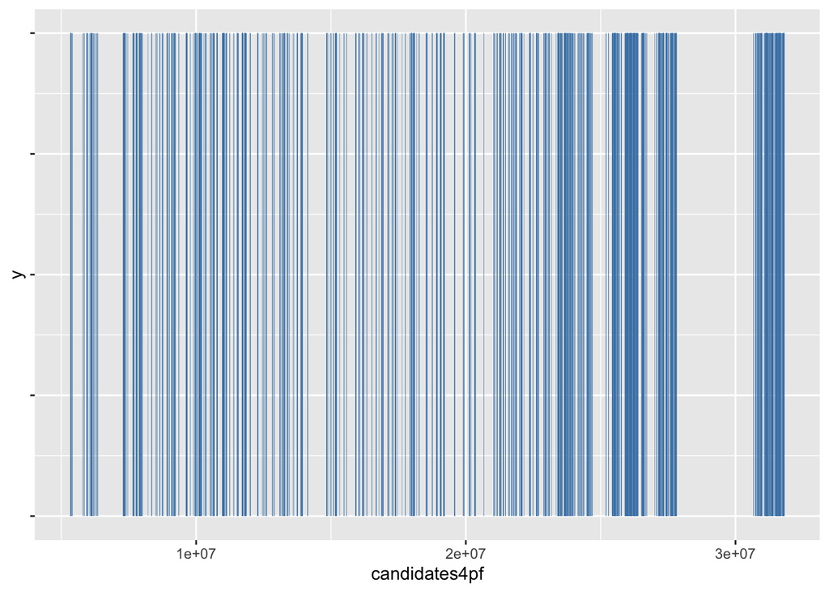

```r
candidates4pf <- read.table("./chromosome_4/chr4_candidates_prefiltering0318.txt")[[1]]

candidates4dfpf <- as.data.frame(candidates4pf)
ggplot(data=candidates4dfpf) +
  geom_segment(aes(x=candidates4pf, xend=candidates4pf+10, y=0, yend=1), color="steelblue", size=0.1) +
  #geom_segment(aes(x=conserved.start, xend=conserved.stop, y=0, yend=1), color="red", size=0.001, alpha=0.05) +
  scale_y_continuous(labels=NULL)
```

Look at distribution of post-filtering candidates:

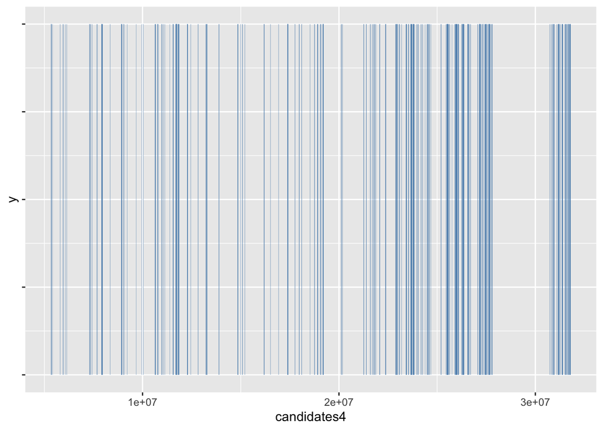

```r
candidates4 <-snp.stats4[,1]
candidates4df <- as.data.frame(candidates4)

ggplot(data=candidates4df) +
  geom_segment(aes(x=candidates4, xend=candidates4+10, y=0, yend=1), color="steelblue", size=0.1) +
  #geom_segment(aes(x=conserved.start, xend=conserved.stop, y=0, yend=1), color="red", size=0.001, alpha=0.05) +
  scale_y_continuous(labels=NULL)
```

Make regions-file to subset vcf with around 401 candidates:

```r
candidates4region <- candidates4df
candidates4region$start <- candidates4region$candidates4-50
candidates4region$stop <- candidates4region$candidates4+50
candidates4region$CHROM <- "Chromosome04"

candidates4region_list <- as.data.frame(cbind(candidates4region$CHROM, candidates4region$start, candidates4region$stop))


rownames(candidates4region_list) <- candidates4region$candidates4
colnames(candidates4region_list) <- c("CHROM","POS","END")

#write.csv(candidates4region_list, "./chromosome_4/candidates4region_list.csv", col.names=FALSE, row.names=FALSE)
```

Read in regional vcf around 401 candidates and format

```r
cand.stats4 <- read.table("./chromosome_4/candidates4.region.stats.txt")
colnames(cand.stats4)[1:4] <- c("POS","REF","ALT","QUAL")
cand.stats4$CAND <- NA
cand.stats4$RANGE <- NA



for (i in 1:length(candidates4)) {
  cand.stats4$CAND[grep(candidates4[i], cand.stats4$POS)] <- candidates4[i]
}

for (i in 1:length(cand.stats4$CAND)) {
  if(!is.na(cand.stats4$CAND[i])){cand.stats4$RANGE[i] <- 0 }
}

cand.pos <- which(cand.stats4$RANGE == 0)

for (i in 1:length(cand.pos)) {
  cand.stats4$RANGE[(cand.pos[i]-50):(cand.pos[i]+50)] <- seq(from=-50, to=50)
}
```

Calculate DP:

```r
# Calculate total DP for all samples:
ADcolnums <- seq(from=8, to=332, by=4)
cand.stats4$DP_SUM <- rowSums(cand.stats4[,ADcolnums])


# Calculate total DP just for non-outlier glaz samples:
glazcolnums <- c(92, 96, 160, 172, 180)
cand.stats4$DP_SUM_glaz <- rowSums(cand.stats4[,glazcolnums])




candidate4.summary <- data.frame()

for (i in 1:length(candidates4))
{
  cand.row = grep(candidates4[i], cand.stats4$CAND)

DP_SUMs_i <- cand.stats4$DP_SUM[(cand.row-50):(cand.row+50)]
mean_i <- mean(DP_SUMs_i)
min_i <- min(DP_SUMs_i)
max_i <- max(DP_SUMs_i)


DP_SUMs_g <- cand.stats4$DP_SUM_glaz[(cand.row-50):(cand.row+50)]
mean_g <- mean(DP_SUMs_g)
min_g <- min(DP_SUMs_g)
max_g <- max(DP_SUMs_g)


candidate4.summary <- rbind(candidate4.summary, c(candidates4[i], mean_i, min_i, max_i, mean_g, min_g, max_g))
}

names(candidate4.summary) <- c("candidate", "meanDP", "minDP", "maxDP", "meanglazDP", "minglazDP", "maxglazDP")
```

Filter by conservation level in surrounding region:

```r
cand.stats4$ALT[cand.stats4$ALT=="."] <- NA
candidate4.summary$other.snps <- NA
where.indels <- nchar(cand.stats4$ALT) > 1 | nchar(cand.stats4$REF) > 1

for (i in 1:length(candidates4)){

  cand.row <- which(grepl(candidates4[i], cand.stats4$CAND))
  lower.range <- cand.row - 50
  upper.range <- cand.row + 50

  other.snps.count <- sum(which(!is.na(cand.stats4$ALT)) %in% lower.range:upper.range)

  indel.cnt <- sum(where.indels[lower.range:upper.range], na.rm=TRUE)


  candidate4.summary[i,"other.snps"] <- other.snps.count
  candidate4.summary[i,"indel.count"] <- indel.cnt
}
```

Visualize summary:

[figure not shown]

```r
hist(candidate4.summary$indel.count)
```

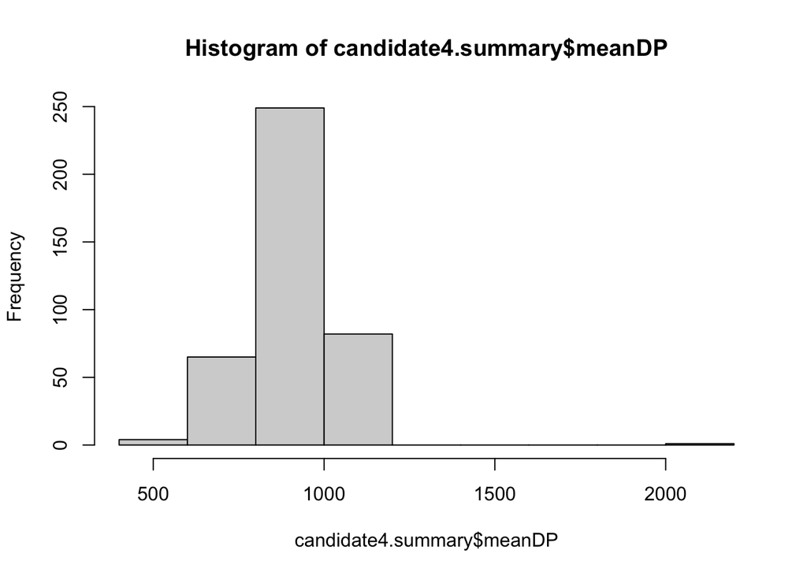

```r
hist(candidate4.summary$meanDP)
```

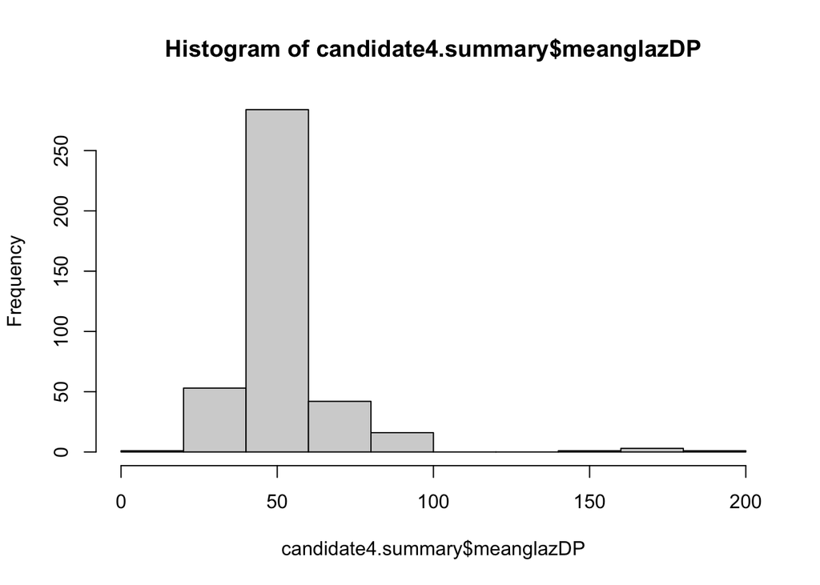

```r
hist(candidate4.summary$meanglazDP)
```

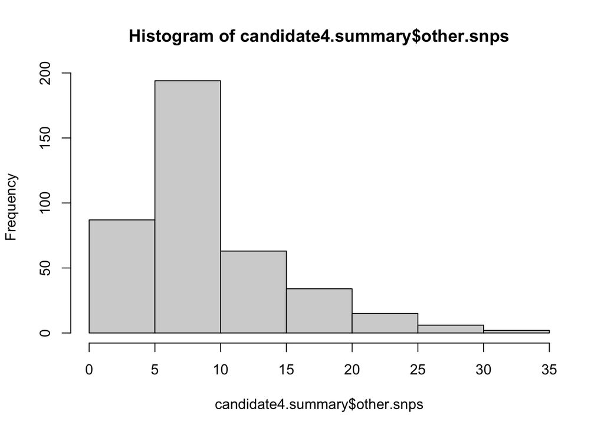

```r
hist(candidate4.summary$other.snps)
```

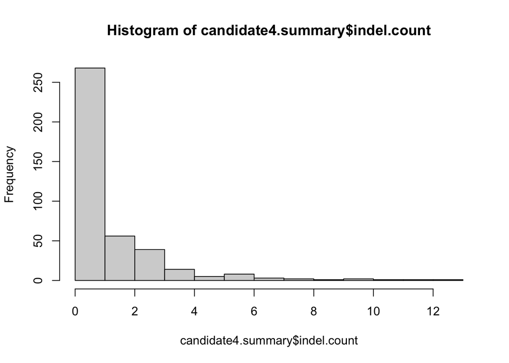

```r
hist(candidate4.summary$indel.count)
```

Filter for best candidates:

```r
#remove sites with more than one indel:
candidate4.summary.noindels <- candidate4.summary[candidate4.summary$indel.count == 0,]
candidate4.summary.noindels.cons <- candidate4.summary.noindels[candidate4.summary.noindels$other.snps < 6,]

#take top 65 candidates with reasonable DP
top.65.candidates <- candidate4.summary.noindels.cons[candidate4.summary.noindels.cons$meanglazDP < 80,]

top.65.candidates <- top.65.candidates[top.65.candidates$meanDP < 1500,]

#take top candidates with lowest number of other nearby SNPs
top.conserved <- slice_max(top.65.candidates, order_by=-other.snps, n=50)

#write.table(top.65.candidates$candidate, "Chr4_glaz_amp_markers", row.names=FALSE, col.names=FALSE)
```

Visualize:

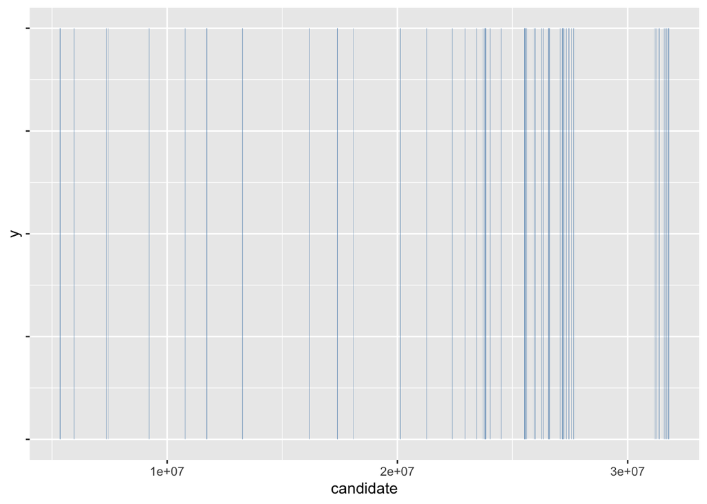

```r
ggplot(data=top.conserved) +
  geom_segment(aes(x=candidate, xend=candidate+10, y=0, yend=1), color="steelblue", size=0.1) +
  #geom_segment(aes(x=conserved.start, xend=conserved.stop, y=0, yend=1), color="red", size=0.001, alpha=0.05) +
  scale_y_continuous(labels=NULL)
```

Filter for distance between markers

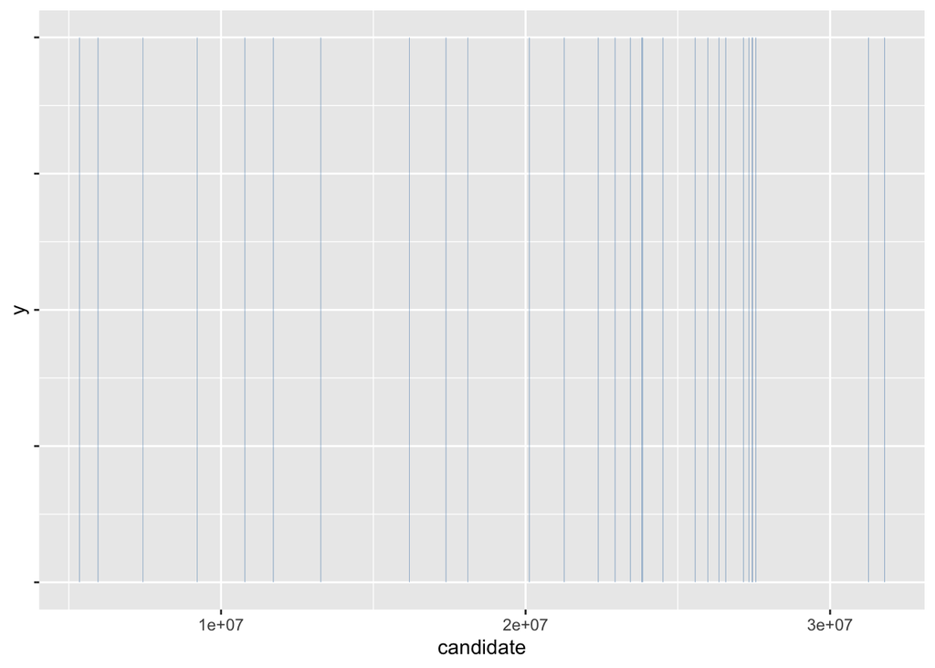

```r
top.conserved.keep = c()
top.conserved.close = c()

for(i in 1:nrow(top.conserved)){
    low.range = top.conserved$candidate[i] - 200000 # look in 200kb region
    top.range = top.conserved$candidate[i] + 200000

    if(length(top.conserved[top.conserved$candidate > low.range
                            & top.conserved$candidate < top.range, 1]) == 1)
      #check if there are candidates close together; keep them if there are none nearby
    {top.conserved.keep = c(top.conserved.keep, i)} else {
      #if there are some close together, pick best one to keep
        top.conserved.close = c(top.conserved.close, i)
        #add to list of those that cluster together

        cluster.rows = which(top.conserved$candidate > low.range & top.conserved$candidate < top.range)
        cluster = top.conserved[cluster.rows,]
        cluster.rep = cluster.rows[which.min(cluster$other.snps)][1]
        #pick the one with lowest other snps or the first one in case of a tie

        top.conserved.keep = c(top.conserved.keep, cluster.rep)
      }
}
top.conserved.keep = unique(top.conserved.keep)

top.conserved.spaced = top.conserved[top.conserved.keep,]

ggplot(data=top.conserved.spaced) +
  geom_segment(aes(x=candidate, xend=candidate+10, y=0, yend=1), color="steelblue", size=0.1) +
  #geom_segment(aes(x=conserved.start, xend=conserved.stop, y=0, yend=1), color="red", size=0.001, alpha=0.05) +
  scale_y_continuous(labels=NULL)
```

```r
#check spacing:
top.ordered = top.conserved.spaced[order(as.numeric(top.conserved.spaced$candidate)),]

for(i in 1:(nrow(top.ordered)-1)){
  if(top.ordered$candidate[i+1]-top.ordered$candidate[i] < 200000 )
     {print(paste0(i, top.ordered$candidate[i+1]-top.ordered$candidate[i]))}
}
```

```
## [1] "1630185"
## [1] "23173415"
## [1] "24116859"
## [1] "251555"
## [1] "26113401"
```

7/9/21: get surrounding sequence information (adapting from Chr 1 code):

```r
library(seqinr)
snp.stats = cand.stats4 #copy dataframes to new names
top.candidates = top.ordered$candidate
top.snps=top.candidates
top.snp.stats = top.ordered

# redo ranges around top snps to make sure they aren't overlapping
snp.stats$CAND <- NA
snp.stats$RANGE <- NA

for (i in 1:length(top.snps)) {
  snp.stats$CAND[grep(top.snps[i], snp.stats$POS)] <- top.snps[i]
}

for (i in 1:length(snp.stats$CAND)) {
  if(!is.na(snp.stats$CAND[i])){snp.stats$RANGE[i] <- 0 }
}

cand.pos <- which(snp.stats$RANGE == 0)

for (i in 1:length(cand.pos)) {
  snp.stats$RANGE[(cand.pos[i]-50):(cand.pos[i]+50)] <- seq(from=-50, to=50)
}



#Initiate columns for IUPAC consensus sequences
top.snp.stats$seq <- NA
top.snp.stats$IUPAC <- NA

snp.stats$problem <- NA

#Flag indels - these will be fixed manually
snp.stats$problem[which(nchar(snp.stats$REF) != 1)] <- "y"

#remove commas from ALT string so multiple alt alleles get included in IUPAC
snp.stats$ALT_collapse <- sub(pattern=",", replacement="", x=snp.stats$ALT)


#make a column for the nucleotide sequence
for (i in 1:nrow(snp.stats)) {
  if (!is.na(snp.stats[i, "ALT"])) {

    #wherever there is an alt allele, paste the ref & alt alleles together in the seq column
  snp.stats[i, "seq"] <- paste(c(snp.stats[i, "REF"], snp.stats[i, "ALT_collapse"]), collapse="")

  #if there is no alt allele, just put the ref allele in the seq column
  } else {
  snp.stats[i, "seq"] <- snp.stats[i, "REF"]
  }

  # make a consensus sequence with bma()
  snp.stats$IUPAC[i] <- bma(unlist(strsplit(snp.stats$seq[i], split="")))



}

#capitalize the consensus
snp.stats$IUPAC <- toupper(snp.stats$IUPAC)

#add a bracket around the candidate SNP
snp.stats$IUPAC <- with(snp.stats, ifelse(!is.na(snp.stats$CAND), paste0("[", REF, "/",ALT_collapse,"]"), IUPAC))

#flag the indel sites
snp.stats$IUPAC <-with(snp.stats, ifelse(nchar(snp.stats$REF) != 1 , paste0("*(", REF, ")"), IUPAC))


#lowercase for low quality sites
snp.stats$IUPAC <- with(snp.stats, ifelse(snp.stats$DP_SUM_glaz < 10 | snp.stats$DP_SUM < 600, tolower(IUPAC), IUPAC))



#write.csv(snp.stats, "~/Desktop/Research/Glaziovii_introgression/chr4.top.snp.stats.IUPAC.csv")
```

Print concatenate sequences to txt and csv files:

```r
consensus_seqlist = list() # initiate list

for (i in 1:length(top.candidates)) {

  this.cand.name <- top.candidates[i]

  row.with.cand <- which(grepl(top.candidates[i], snp.stats$CAND))

  this.cand  <- snp.stats[(row.with.cand-50):(row.with.cand+50),]

    this.cand <- this.cand[,c(1:4,334:340)]
    #select POS, REF, ALT, QUAL, RANGE, seq, IUPAC,

    this.cand.df <- data.frame("POS"=this.cand$POS,
                               "Range"=this.cand$RANGE,
                               "REF"=this.cand$REF,
                               "ALT"=this.cand$ALT,
                               "seq" = this.cand$seq,
                               "IUPAC" = this.cand$IUPAC)


    consensus.seq <- paste(this.cand.df$IUPAC, collapse="")

    consensus_seqlist[[i]] <- consensus.seq # add it to the main list

    names(consensus_seqlist[[i]]) <- top.candidates[i]
}


folder <- "~/Desktop/Research/Glaziovii_introgression/chromosome_4/candidate_consensus_seqs_chr4/"
all.cand.seq.df <- data.frame(matrix(ncol = 2, nrow = length(consensus_seqlist)))
names(all.cand.seq.df) <- c("candidate","consensus")


for (i in 1:length(consensus_seqlist)) {

filepath <- paste(folder, names(consensus_seqlist[[i]]), '.txt', sep="")
#write.table(consensus_seqlist[[i]], filepath, sep="\n")

  all.cand.seq.df[i,2] <- consensus_seqlist[[i]]
  all.cand.seq.df[i,1] <- names(consensus_seqlist[[i]])

}

#write.csv(all.cand.seq.df, paste0(folder,"chr4.topcandidate.consensus.csv"))
```

print REF/ALT list and final file:

```r
REF.ALT.list <- snp.stats[which(!is.na(snp.stats$CAND)), c(2:3, 333)]
#select REF, ALT, CAND

all.cand.seq.alleles = merge(all.cand.seq.df, REF.ALT.list, by.x="candidate", by.y="CAND")

colnames(all.cand.seq.alleles)[1] <- "v7_position"

#reorder and renumber rows:
all.cand.seq.alleles = all.cand.seq.alleles[order(as.numeric(all.cand.seq.alleles$v7_position)),]
rownames(all.cand.seq.alleles) = 1:nrow(all.cand.seq.alleles)

#write.csv(all.cand.seq.alleles, paste0(folder,"chr4.topcandidate.consensus.csv"))
```

OLD For future reference: read in a VCF:

```r
library(vcfR)
chr4cand.regions <- read.vcfR("./chromosome_4/intrgr.chr4.401cand.region.vcf")
```

[output not shown]

```r
chr4cand.regions.df <- create.chromR(chr4cand.regions)
```

```
## Names in vcf:
```

```
##   Chromosome04
```

```
## Initializing var.info slot.
```

```
## var.info slot initialized.
```

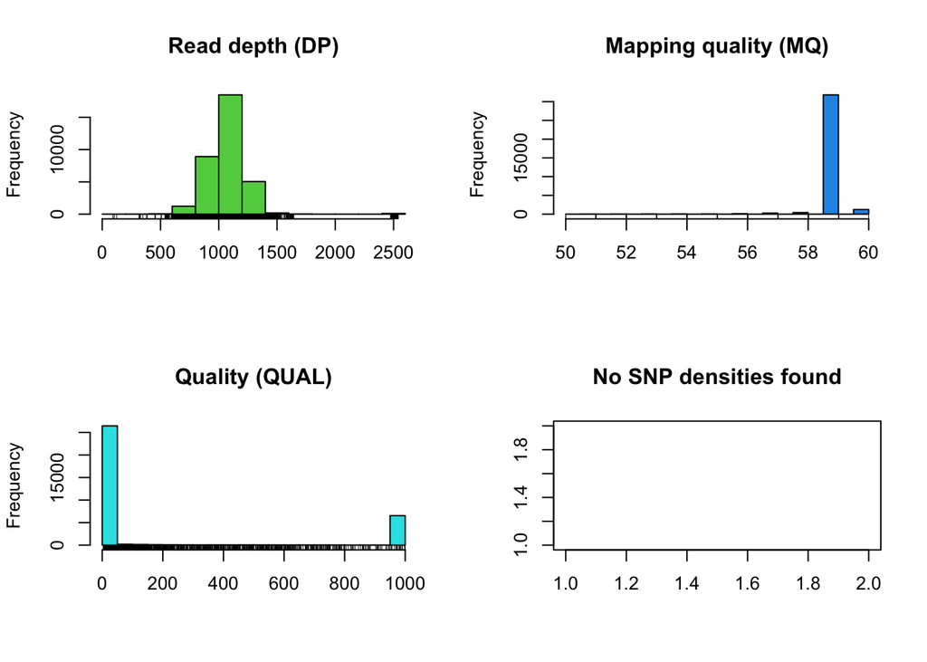

```r
plot(chr4cand.regions.df)
```

visualize distribution of markers for markers on chr1 and chr4:

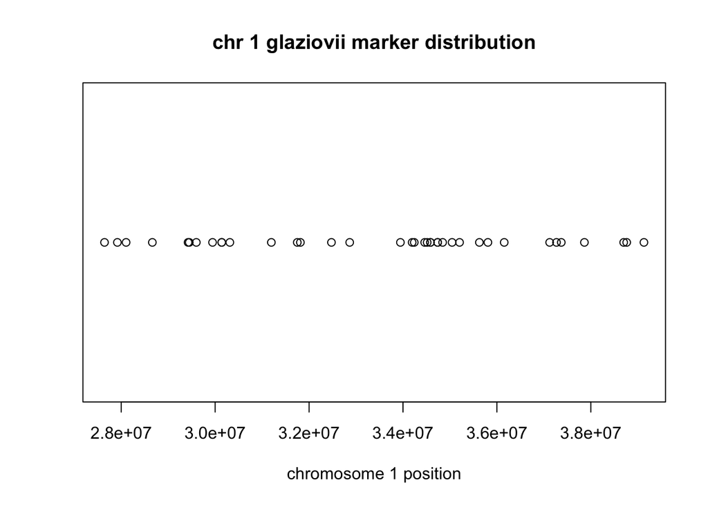

```r
chr1markers <- read.table("Chr1_glaz_KASP_markers.txt")[,1]
chr1markers.y <- rep(1, length(chr1markers))
plot(chr1markers, chr1markers.y,
     ylab="", xlab="chromosome 1 position",
     main="chr 1 glaziovii marker distribution",
     yaxt="n")
```

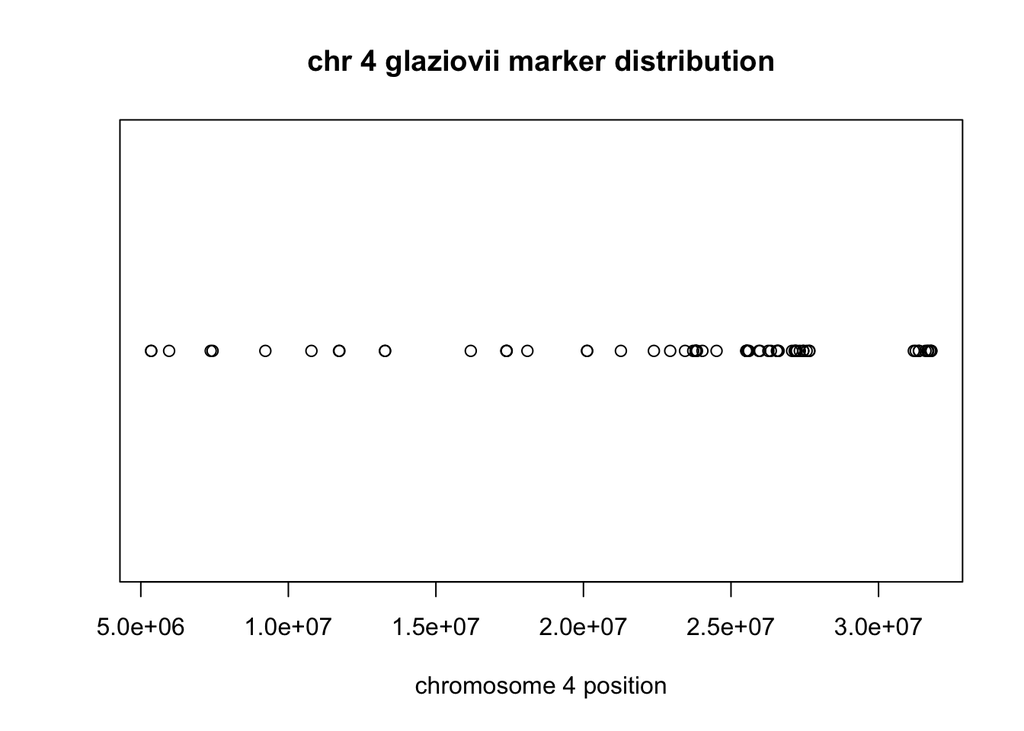

```r
chr4markers <- read.table("Chr4_glaz_amp_markers")[,1]
chr4markers.y <- rep(1, length(chr4markers))

plot(chr4markers, chr4markers.y,
     ylab="", xlab="chromosome 4 position",
     main="chr 4 glaziovii marker distribution",
     yaxt="n")
```